# Multiple Correspondence Analysis: Assignments

Neli Noykova

# MULTIPLE CORRESPONDANCE ANALYSIS - Assignment 1

conducted by Neli Noykova.

# The data

In this exercise set we use **Finnish** sample from [ISSP 2012 survey “Family and Changing Gender Roles IV”](http://www.gesis.org/issp/modules/issp-modules-by-topic/family-and-changing-gender-roles/2012/). Original data involve 1171 observations of 8 variables (4 substantive and 4 demographic). All variables are categorical.

The 4 **substantive** variables, which values are masured in 1-5 scale, are:

**A**: Married people are generally happier than unmarried people. **B**: People who want children ought to get married. **C**: It is all right for a couple to live together without intending to get married. **D**: Divorce is usually the best solution when a couple can’t seem to work out their marriage problems.

The **demographic** variables are: **g**: gender (1=male, 2=female) **a**: age group (1=16-25, 2=26-35, 3=36-45, 4=46-55, 5=56-65, 6= 66+) **e**: education (1=Primary, 2=Comprehensive, primary and lower secondary, 3= Post-comprehensive, vocational school or course, 4=General upper secondary education or certificate, 5= Vocational post-secondary non-tertiary education, 6=Polytechnics , 7= University, lower academic degree, BA, 8=University, higher academic degree, MA **p**: Living in steady partnership (1=Yes, have partner; live in same household, 2=Yes, have partner; don’t live in same household, 3=No partner)

The data wrangling includes the following changes:

1. The missing data ae removed (this has already been provided). The number of observations without missing data is N=924.
2. For Task 2 a combined variable **ga**, describing the intraction of gender and age categories, is formed as: **ga = 6*(g-1) + a**

## Graphical overview of the data and summaries of the variables

The preliminary treated data look as:

```r
Finland <- read.table("Finland.txt")
head(Finland)
```

```
##   A B C D g a e p
## 1 3 3 1 2 1 2 4 3
## 2 3 2 3 2 1 4 2 3
## 3 3 3 1 3 1 3 8 1
## 4 3 2 2 3 2 2 6 1
## 5 2 2 2 3 2 4 5 1
## 6 3 3 1 3 1 3 7 3
```

```r
dim(Finland)
```

```
## [1] 924   8
```

```r
str(Finland)
```

```
## 'data.frame':    924 obs. of  8 variables:
##  $ A: int  3 3 3 3 2 3 3 2 2 3 ...
##  $ B: int  3 2 3 2 2 3 3 3 3 3 ...
##  $ C: int  1 3 1 2 2 1 1 1 2 3 ...
##  $ D: int  2 2 3 3 3 3 2 2 3 3 ...
##  $ g: int  1 1 1 2 2 1 2 2 2 2 ...
##  $ a: int  2 4 3 2 4 3 1 2 5 4 ...
##  $ e: int  4 2 8 6 5 7 4 8 7 5 ...
##  $ p: int  3 3 1 1 1 3 3 3 1 3 ...
```

# Task 1: Cross-tabulations and correspondance analysis (CA).

The goal is to discover interesting relations among the measurements on A, …, D, g, …, p. Correspondence analysis is a descriptive/exploratory technique designed to analyse simple two-way and multi-way tables containing some measure of correspondence between the rows and columns. CA may also be defined as a special case of Principal Components Analysis of the rows and columns of a table, especially applicable to a cross-tabulation. Principal components analysis is used for tables consisting of continuous measurement, whereas CA is applied to contingency tables (i.e. cross-tabulations). The goal of CA is to transform a table of numerical information into a graphical display, in which each row and each column is depicted as a point. Thus CA can be used for data visualization or data pre-processing before applying methods for supervised learning. We can apply this technique for dimensionality reduction.

First we provide a cross-tabulation between the age variable **a** and answer **A**: Married people are generally happier than unmarried people. The variable **a** consists of 6 age groups, corresponding to rownames of crosstable: **a1** = 16-25, **a2**=26-35, **a3** = 36-45, **a4** = 46-55, **a5** = 56-65, **a6** = 66+ The categorical variable **A** assume 5 possible values, which correspond to column names of cross-table: **SA** - strongly agree; **A** - agree, **NN** - neither agree or disagree, **D** - disagree, **SD** - strongly disagree.

```r
tab <-table(Finland[,"a"], Finland[,"A"])

rownames(tab) <- c("a1","a2","a3","a4","a5","a6")
colnames(tab) <- c("SA","A","NN","D","SD")

tab
```

```
##
##      SA  A NN  D SD
##   a1  5 18 42 29 29
##   a2  6 25 44 34 34
##   a3  6 30 55 30 17
##   a4  9 37 60 46 34
##   a5 15 67 58 49 15
##   a6  5 37 56 26  6
```

From this table we see that the biggest part of age group **a5** agree with question **A**. Since these values are absolute, we need more precise information wich could be obtained row and column profiles, calculated from this cross-table. We need also to calculate the chi-square statistic as it has been shown durint the second exercise session.

An alternative means of extracting the nature of the dependency between the rows and columns of the contingency table is to represent the row or column profiles graphically.

```r
require(ca)
```

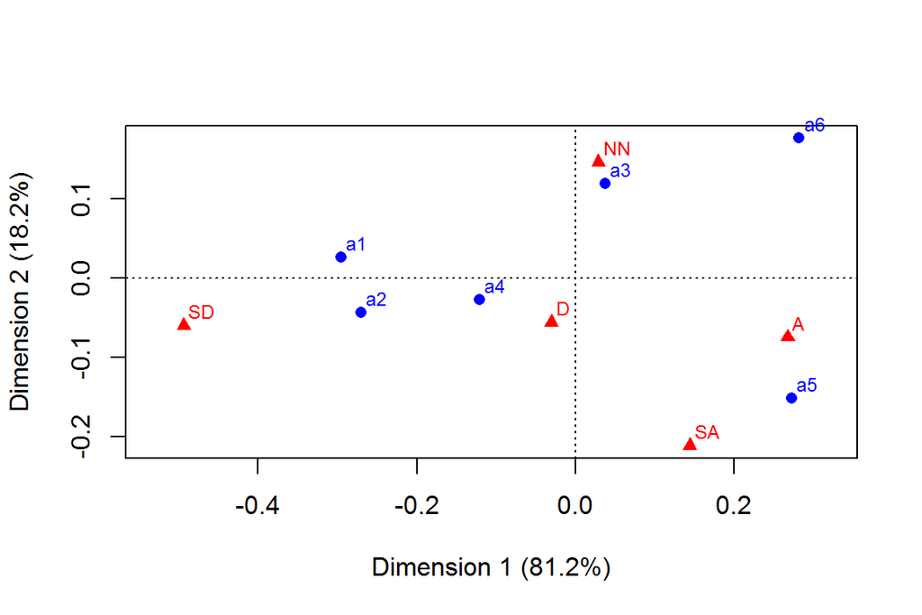

```r
plot(ca(tab))
```

As a second example we conduct cross-tabulation between the variable **p** (if there is a partner and they live together) and answer **C*: C: It is all right for a couple to live together without intending to get married. The obtained cross-table and resulting plot from CA are:

```r
#Cross-tabulations
#between g and D
tab2 <-table(Finland[,"p"], Finland[,"C"])

rownames(tab2) <- c("Live together","Not live together", "No partner")
colnames(tab2) <- c("SA","A","NN","D","SD")
tab2
```

```
##
##                      SA   A  NN   D  SD
##   Live together     291 247  44  32  29
##   Not live together  26  10   5   1   0
##   No partner        119  79  15  11  15
```

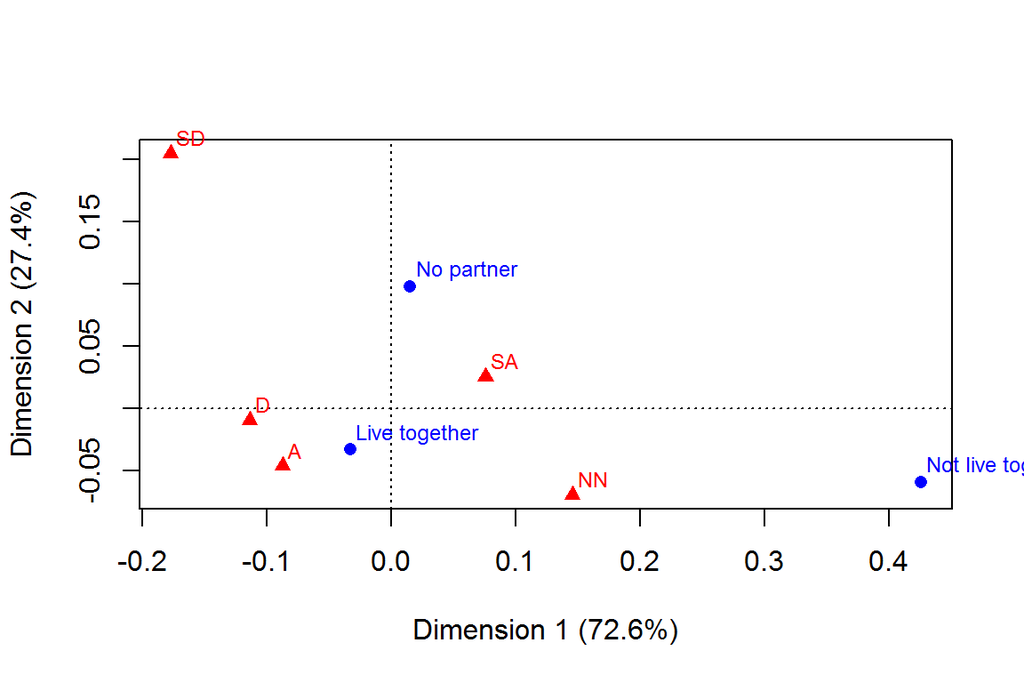

```r
require(ca)
plot(ca(tab2))
```

From the cross-tabulation and CA plot becomes clear that people, who live together, tend to give positive answer to the statement **C**.

As a third example we investigate relationship between education **e** and statement **A**:

```r
tab1 <-table(Finland[,"e"], Finland[,"A"])
rownames(tab1) <- c("Primary","Comprehensive", "Post-comprehensive", "General", "Vocational", "Polytechnics", "University, B", "University, MSc")
colnames(tab1) <- c("SA","A","NN","D","SD")
tab1
```

```
##
##                      SA  A NN  D SD
##   Primary             3 28 34 14  3
##   Comprehensive       6  9 18 16 10
##   Post-comprehensive 16 37 71 54 26
##   General             1 20 39 18 18
##   Vocational          4 49 63 53 39
##   Polytechnics        7 25 28 22 16
##   University, B       2 11 23 16  5
##   University, MSc     7 35 39 21 18
```

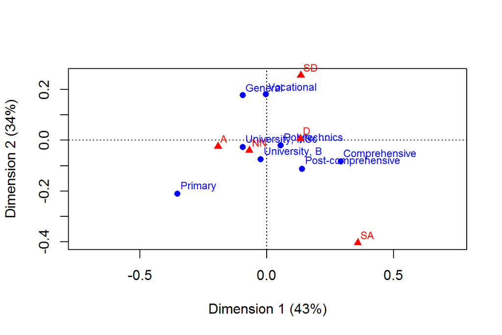

```r
require(ca)
plot(ca(tab1))
```

From this plot becomes clear that no one of the educational gruops strongly afrees with the statement **A**. The highly educated people with university degrees tend to answer using middle alternative.

## Task 2: Cross-tabulation of **ga** demographic variable against one of the substantive variables. Performing CA.

The variable **ga**, which is the interaction of gender and age categories, is created as:

```r
Finland$ga <- 6*(Finland$g-1) + Finland$a
head(Finland)
```

```
##   A B C D g a e p ga
## 1 3 3 1 2 1 2 4 3  2
## 2 3 2 3 2 1 4 2 3  4
## 3 3 3 1 3 1 3 8 1  3
## 4 3 2 2 3 2 2 6 1  8
## 5 2 2 2 3 2 4 5 1 10
## 6 3 3 1 3 1 3 7 3  3
```

```r
str(Finland)
```

```
## 'data.frame':    924 obs. of  9 variables:
##  $ A : int  3 3 3 3 2 3 3 2 2 3 ...
##  $ B : int  3 2 3 2 2 3 3 3 3 3 ...
##  $ C : int  1 3 1 2 2 1 1 1 2 3 ...
##  $ D : int  2 2 3 3 3 3 2 2 3 3 ...
##  $ g : int  1 1 1 2 2 1 2 2 2 2 ...
##  $ a : int  2 4 3 2 4 3 1 2 5 4 ...
##  $ e : int  4 2 8 6 5 7 4 8 7 5 ...
##  $ p : int  3 3 1 1 1 3 3 3 1 3 ...
##  $ ga: num  2 4 3 8 10 3 7 8 11 10 ...
```

```r
tab3 <-table(Finland[,"ga"], Finland[,"C"])
rownames(tab3) <- c("Ma1","Ma2", "Ma3", "Ma4", "Ma5", "Ma6", "Fa1","Fa2", "Fa3", "Fa4", "Fa5", "Fa6")
colnames(tab3) <- c("SA","A","NN","D","SD")
tab3
```

```
##
##       SA  A NN  D SD
##   Ma1 30 11  3  0  4
##   Ma2 46 15  0  1  0
##   Ma3 26 31  0  4  1
##   Ma4 38 38  7  2  2
##   Ma5 29 36  9  7  3
##   Ma6  8 37  6  8  2
##   Fa1 38 21  1  6  9
##   Fa2 59 16  1  0  5
##   Fa3 43 25  4  2  2
##   Fa4 63 24  7  2  3
##   Fa5 42 45 18  8  7
##   Fa6 14 37  8  4  6
```

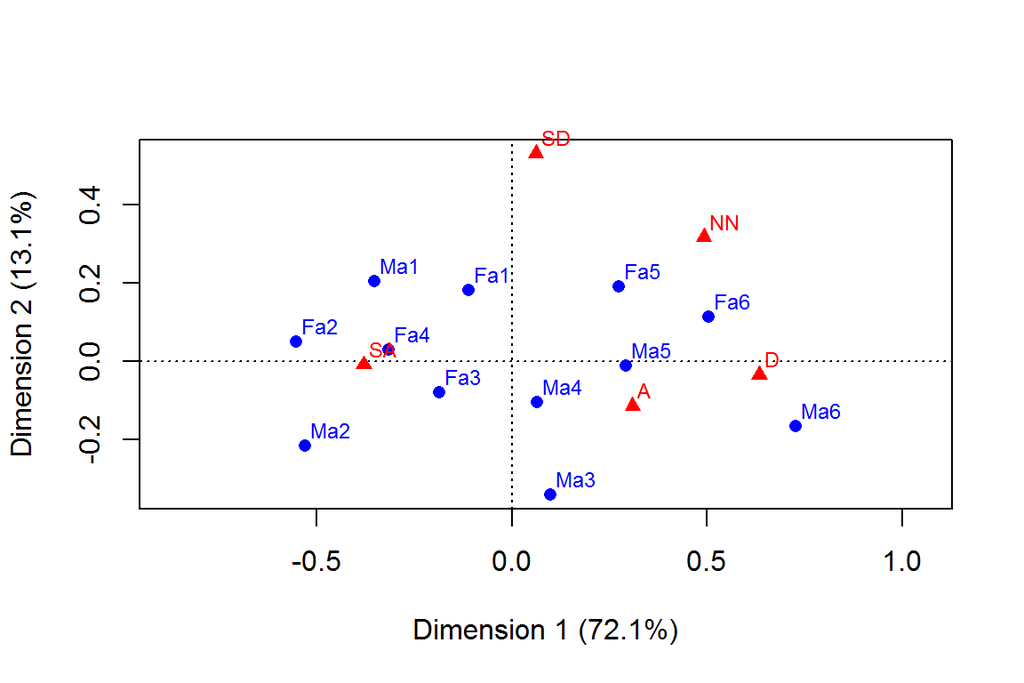

```r
require(ca)
plot(ca(tab3))
```

## Task 3:Computation of the Burt matrix on the questions and demographics together.

The most classical and standard approach to MCA is to apply a simple CA to the indicatormatrix Z. The indicator matrix Z = {zij} corresponds to a binary coding of the factors - instead of using a factor with Jq levels one uses Jq columns containing binary values, also called dummy variables. The Burt matrix C is obtained directly from the indicator matrix Z: C = ZTZ. Burt matrix concatenates all two-way cross-tabulations between pairs of variables

The Burt matrix is computed as:

```r
require(ca)
Finland.B <- mjca(Finland)$Burt
head(Finland.B)
```

```
##     A:1 A:2 A:3 A:4 A:5 B:1 B:2 B:3 B:4 B:5 C:1 C:2 C:3 C:4 C:5 D:1 D:2
## A:1  46   0   0   0   0  28  12   4   2   0  15  13   6   6   6  13  15
## A:2   0 214   0   0   0  50  92  38  25   9  64 101  17  15  17  28  91
## A:3   0   0 315   0   0  24  92  95  83  21 145 120  30  14   6  55 115
## A:4   0   0   0 214   0  15  42  30  97  30 104  88  10   9   3  41  84
## A:5   0   0   0   0 135   9  10   6  24  86 108  14   1   0  12  40  43
## B:1  28  50  24  15   9 126   0   0   0   0  26  34  17  15  34  29  24
##     D:3 D:4 D:5 g:1 g:2 a:1 a:2 a:3 a:4 a:5 a:6 e:1 e:2 e:3 e:4 e:5 e:6
## A:1   5   7   6  28  18   5   6   6   9  15   5   3   6  16   1   4   7
## A:2  46  36  13 113 101  18  25  30  37  67  37  28   9  37  20  49  25
## A:3  88  43  14 136 179  42  44  55  60  58  56  34  18  71  39  63  28
## A:4  41  43   5  85 129  29  34  30  46  49  26  14  16  54  18  53  22
## A:5  27  12  13  42  93  29  34  17  34  15   6   3  10  26  18  39  16
## B:1  20  29  24  59  67  15   8  16  16  41  30  15  10  27  12  32   7
##     e:7 e:8 p:1 p:2 p:3 ga:1 ga:2 ga:3 ga:4 ga:5 ga:6 ga:7 ga:8 ga:9 ga:10
## A:1   2   7  35   1  10    3    3    4    6   10    2    2    3    2     3
## A:2  11  35 171   8  35   10   12   16   22   29   24    8   13   14    15
## A:3  23  39 224  12  79   16   21   21   32   21   25   26   23   34    28
## A:4  16  21 141  14  59    8   14   13   20   20   10   21   20   17    26
## A:5   5  18  72   7  56   11   12    8    7    4    0   18   22    9    27
## B:1   4  19  97   2  27    7    3    8    8   19   14    8    5    8     8
##     ga:11 ga:12
## A:1     5     3
## A:2    38    13
## A:3    37    31
## A:4    29    16
## A:5    11     6
## B:1    22    16
```

```r
summary(Finland.B)
```

```
##       A:1              A:2              A:3              A:4
##  Min.   : 0.000   Min.   :  0.00   Min.   :  0.00   Min.   :  0.00
##  1st Qu.: 3.000   1st Qu.: 13.00   1st Qu.: 21.00   1st Qu.: 14.00
##  Median : 6.000   Median : 25.00   Median : 34.00   Median : 22.00
##  Mean   : 8.118   Mean   : 37.76   Mean   : 55.59   Mean   : 37.76
##  3rd Qu.:10.000   3rd Qu.: 38.00   3rd Qu.: 67.00   3rd Qu.: 44.50
##  Max.   :46.000   Max.   :214.00   Max.   :315.00   Max.   :214.00
##       A:5              B:1              B:2              B:3
##  Min.   :  0.00   Min.   :  0.00   Min.   :  0.00   Min.   :  0.00
##  1st Qu.:  6.50   1st Qu.:  8.00   1st Qu.: 14.00   1st Qu.: 10.00
##  Median : 13.00   Median : 16.00   Median : 27.00   Median : 20.00
##  Mean   : 23.82   Mean   : 22.24   Mean   : 43.76   Mean   : 30.53
##  3rd Qu.: 28.00   3rd Qu.: 27.50   3rd Qu.: 52.00   3rd Qu.: 37.50
##  Max.   :135.00   Max.   :126.00   Max.   :248.00   Max.   :173.00
##       B:4              B:5              C:1              C:2
##  Min.   :  0.00   Min.   :  0.00   Min.   :  0.00   Min.   :  0.00
##  1st Qu.: 13.50   1st Qu.:  5.00   1st Qu.: 26.00   1st Qu.: 19.50
##  Median : 25.00   Median : 16.00   Median : 59.00   Median : 36.00
##  Mean   : 40.76   Mean   : 25.76   Mean   : 76.94   Mean   : 59.29
##  3rd Qu.: 50.50   3rd Qu.: 31.50   3rd Qu.:102.50   3rd Qu.: 77.00
##  Max.   :231.00   Max.   :146.00   Max.   :436.00   Max.   :336.00
##       C:3             C:4              C:5              D:1
##  Min.   : 0.00   Min.   : 0.000   Min.   : 0.000   Min.   :  0.00
##  1st Qu.: 3.00   1st Qu.: 2.000   1st Qu.: 2.000   1st Qu.: 12.00
##  Median : 7.00   Median : 5.000   Median : 5.000   Median : 22.00
##  Mean   :11.29   Mean   : 7.765   Mean   : 7.765   Mean   : 31.24
##  3rd Qu.:17.00   3rd Qu.:12.000   3rd Qu.: 9.500   3rd Qu.: 38.00
##  Max.   :64.00   Max.   :44.000   Max.   :44.000   Max.   :177.00
##       D:2              D:3              D:4              D:5
##  Min.   :  0.00   Min.   :  0.00   Min.   :  0.00   Min.   : 0.0
##  1st Qu.: 22.50   1st Qu.: 15.00   1st Qu.: 10.00   1st Qu.: 3.5
##  Median : 37.00   Median : 22.00   Median : 15.00   Median : 6.0
##  Mean   : 61.41   Mean   : 36.53   Mean   : 24.88   Mean   : 9.0
##  3rd Qu.: 85.00   3rd Qu.: 45.50   3rd Qu.: 30.50   3rd Qu.:11.0
##  Max.   :348.00   Max.   :207.00   Max.   :141.00   Max.   :51.0
##       g:1              g:2              a:1              a:2
##  Min.   :  0.00   Min.   :  0.00   Min.   :  0.00   Min.   :  0.00
##  1st Qu.: 26.50   1st Qu.: 33.50   1st Qu.:  0.00   1st Qu.:  0.00
##  Median : 61.00   Median : 76.00   Median : 13.00   Median : 17.00
##  Mean   : 71.29   Mean   : 91.76   Mean   : 21.71   Mean   : 25.24
```

[output cut: 36 more lines]

```
##  Max.   :62.00   Max.   :62.00   Max.   :87.00   Max.   :84.00
##       ga:6            ga:7            ga:8            ga:9
##  Min.   : 0.00   Min.   : 0.00   Min.   : 0.00   Min.   : 0.00
##  1st Qu.: 0.00   1st Qu.: 0.00   1st Qu.: 0.00   1st Qu.: 0.00
##  Median : 4.00   Median : 6.00   Median : 5.00   Median : 4.00
##  Mean   :10.76   Mean   :13.24   Mean   :14.29   Mean   :13.41
##  3rd Qu.:12.50   3rd Qu.:19.50   3rd Qu.:19.50   3rd Qu.:17.50
##  Max.   :61.00   Max.   :75.00   Max.   :81.00   Max.   :76.00
##      ga:10           ga:11            ga:12
##  Min.   : 0.00   Min.   :  0.00   Min.   : 0.00
##  1st Qu.: 0.00   1st Qu.:  0.00   1st Qu.: 0.00
##  Median : 6.00   Median : 10.00   Median : 5.00
##  Mean   :17.47   Mean   : 21.18   Mean   :12.18
##  3rd Qu.:24.00   3rd Qu.: 27.00   3rd Qu.:15.50
##  Max.   :99.00   Max.   :120.00   Max.   :69.00
```

We take the stacked tables of **A** and **D** substantive variables from the whole Burt matrix:

```r
Finland.AD = Finland.B[c(1:5,16:20), c(1:5,16:20)]
```

```r
summary(Finland.AD)
```

```
##       A:1            A:2             A:3              A:4
##  Min.   : 0.0   Min.   :  0.0   Min.   :  0.00   Min.   :  0.0
##  1st Qu.: 0.0   1st Qu.:  0.0   1st Qu.:  0.00   1st Qu.:  0.0
##  Median : 5.5   Median : 20.5   Median : 28.50   Median : 23.0
##  Mean   : 9.2   Mean   : 42.8   Mean   : 63.00   Mean   : 42.8
##  3rd Qu.:11.5   3rd Qu.: 43.5   3rd Qu.: 79.75   3rd Qu.: 42.5
##  Max.   :46.0   Max.   :214.0   Max.   :315.00   Max.   :214.0
##       A:5              D:1              D:2              D:3
##  Min.   :  0.00   Min.   :  0.00   Min.   :  0.00   Min.   :  0.00
##  1st Qu.:  0.00   1st Qu.:  0.00   1st Qu.:  0.00   1st Qu.:  0.00
##  Median : 12.50   Median : 20.50   Median : 29.00   Median : 16.00
##  Mean   : 27.00   Mean   : 35.40   Mean   : 69.60   Mean   : 41.40
##  3rd Qu.: 36.75   3rd Qu.: 40.75   3rd Qu.: 89.25   3rd Qu.: 44.75
##  Max.   :135.00   Max.   :177.00   Max.   :348.00   Max.   :207.00
##       D:4              D:5
##  Min.   :  0.00   Min.   : 0.0
##  1st Qu.:  0.00   1st Qu.: 0.0
##  Median :  9.50   Median : 5.5
##  Mean   : 28.20   Mean   :10.2
##  3rd Qu.: 41.25   3rd Qu.:13.0
##  Max.   :141.00   Max.   :51.0
```

The computation of MCA is the application of the (simple) CA algorithm to the Burt matrix C.

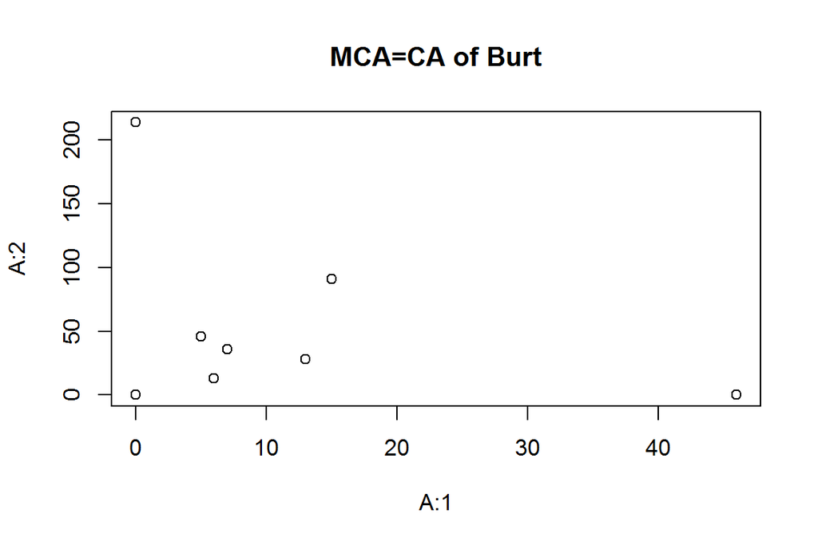

```r
plot(Finland.AD, main="MCA=CA of Burt")
```

## Task 4: Multiple correspondence analysis (MCA) on the four substantive questions.

Here I use the script from Exercise set 2 about joint correspondance analysis and its fit to two-way tables:

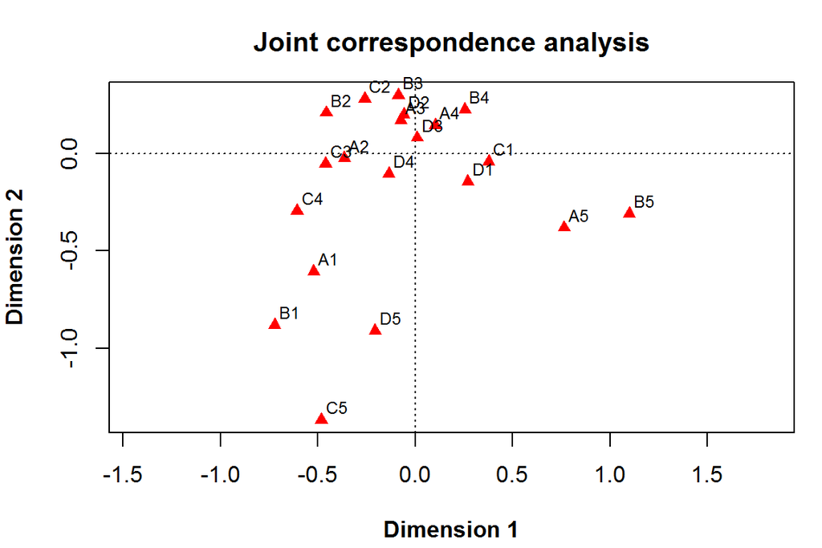

```r
Finland.mca <- mjca(Finland[,1:4], ps="", lambda="JCA")
par(mar=c(4.2,4,3,1), mfrow=c(1,1), font.lab=2)
plot(Finland.mca, main="Joint correspondence analysis")
```